# Práctica III: Transformadas para el análisis de sistemas lineales

Karen del Rey y Álvaro López

10 de noviembre de 2020

# 1. Prelaboratorio: Transformada Z

## 1.1. Efectos de audio

Dado el siguiente diagrama de bloques, correspondiente a un sistema para producir efectos de audio, determina su función de transferencia en función de (D1, D2, D3, G1 y G2) y su respuesta impulsional (ayuda: considéralo como tres sistemas en paralelo).

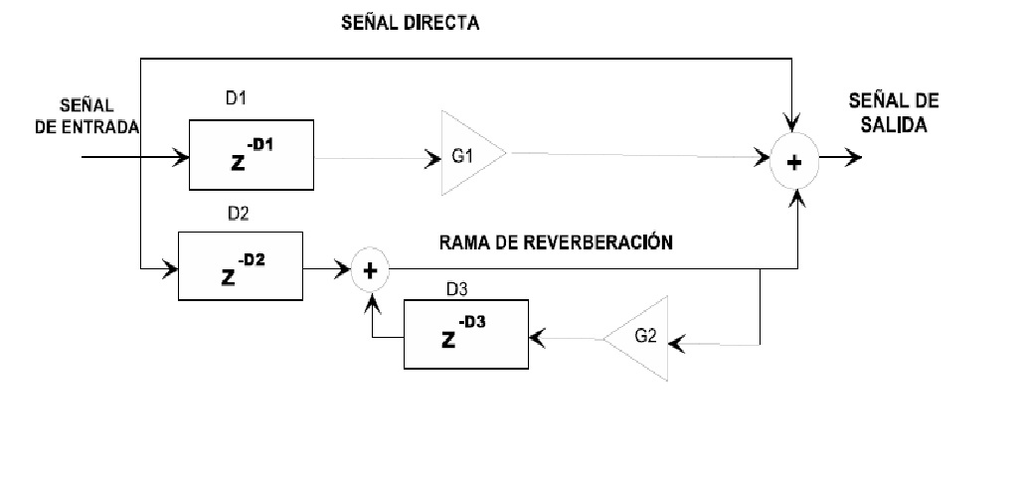

$$Y(n)= Y_{1} + Y_{2} + Y_{3}$$
Trasladamos las expresiones al Dominio Z para operar con más facilidad:
$$Y_{1} = x$$
$$Y_{2} (n) = G_{1} * x(n-D_{1}) \to Y_{2} (z) = G_{1} * xz^{-D1}$$
$$Y_{3} (n) = x(n-D2) + G2 * Y_{3}(N-D3) \to Y_{3} (z) = xz^{-D2}+G2*Y_{3}z^{-D3}$$
$$Y_{3} (z) = \frac{xz^{-D2}}{1-G2z^{-D3}}$$
Sustituimos para generar la salida del sistema:

$$H(z) = x + G1*xz^{-D1}+ \frac{xz^{-D2}}{1-G2z^{-D3}} =$$
$$H(z) =\frac{x(1-G2z^{-D3})+G1*xz^{-D1}(1-G2z^{-D3})+xz^{-D2}}{1-G2z^{-D3}}$$
Función de transferencia en función de (D1, D2, D3, G1 y G2):

$$Y(n)=x(n)-G2x(n-D3)+G1x(n-D1)-G2x(n-D3)(G1x(n-D1))+x(n-D2)+G2Y(n-D3)$$
$$Y(n)=x(n)-G2x(n-D3)+G1x(n-D1)-G2G1x(n-(D3+D1)+x(n-D2)+G2Y(n-D3)$$

## 1.2. Sistema IIR

Un sistema digital tiene como respuesta impulsional la serie infinita h(n) definida como:

$$h(n) = \{ 0,1,2,3,0,1,2,3\}$$
Esta señal se denomina diente de sierra. Calcular su función de transferencia H(z), comprobando la solucion en R utilizando la instrucción impz.

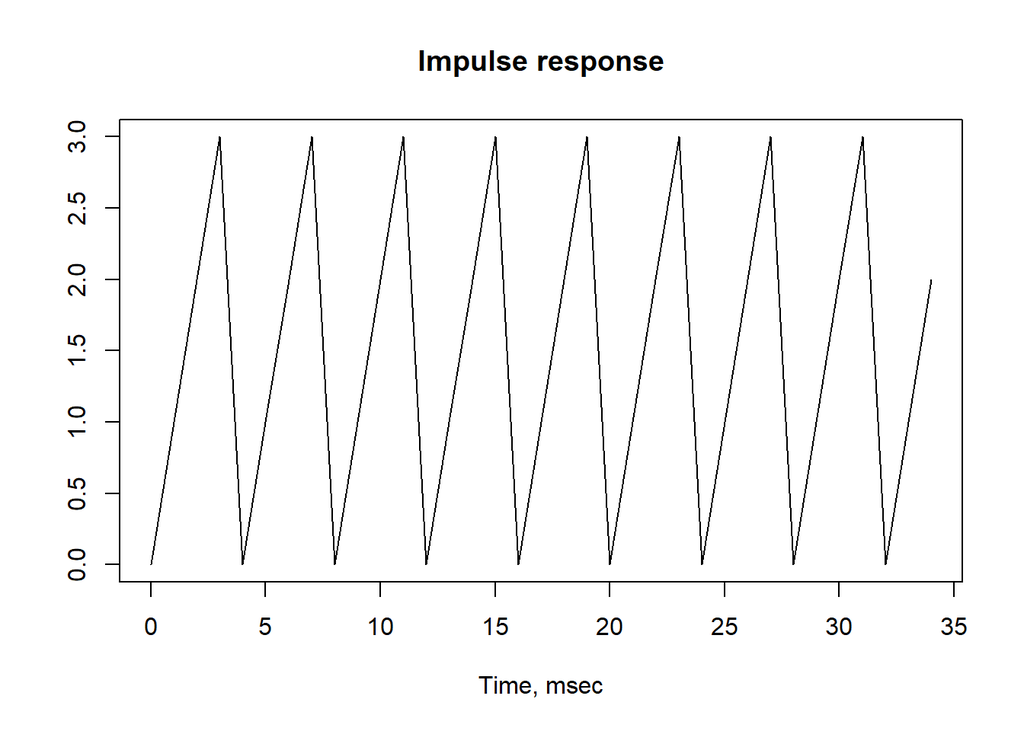

```r
library("signal") # importamos biblioteca
# definimos vectores
x<-c(0,1,2,3)
y<-c(1,0,0,0,-1)
#  El -1 tiene hace referencia al vector antes (feedback) retroalimentacion B son los parámetros definidos
impz(x,y,35)
```